# Lab 07: Causal methods

Required packages:

- `carData`: for the Rossi data set on arrests and financial aid.
- `AER`: for robust standard errors.
- `boot`: for bootstrapping.
- `causalweight`: for the IPW ATE estimator.
- `devtools`: for installation of packages from github repositories.
- `causalTree`: for causal tree methods.
- `grf`: for causal forests.
- `hdm`: for Lasso
- `kableExtra`: for nicer tables.

```r
library(carData)
library(stargazer)
library(AER)
library(knitr)
library(kableExtra)
```

# Research question

Does receiving financial aid reduces the probability of a convict being re-arrested after a release?

One can argue that receiving financial aid can help released convicts to focus on finding jobs and re-integrating. One can also argue that it reduces incentives to commit crimes.

It is important to assess if financial aid helps with re-integration into the society. It is also important to assess the magnitude of the effect as financial aid programs can be costly to tax-payers. If such programs are not effective, we should spend the funds on other more effective rehabilitation programs.

If the effect of the program can be heterogeneous, it is important to identify sub-populations where the program is more effective. This would allow policy makers to target released convicts for whom the effect is expected to be more substantial.

# Data set preparations:

Let’s construct `Wks`: % of time unemployed before re-arrest or until the end of the period:

```r
N<-nrow(Rossi)
Rossi$Weeks_worked<-0
for (i in 1:N){
  last_week_col<-Rossi$week[i]+10 #last week before arrest column number
  for (j in 11:last_week_col){
  Rossi$Weeks_worked[i]<-Rossi$Weeks_worked[i]+(Rossi[i,j]=="yes")
  }
}
Rossi$Wks<-(Rossi$week-Rossi$Weeks_worked)/Rossi$week
```

Creat a 0/1 treatment variable:

```r
Rossi$D<-(Rossi$fin=="yes")+0
```

Education is a factor:

```r
Rossi$Grades<-" "
Rossi$Grades[Rossi$educ==2]<-"_6"
Rossi$Grades[Rossi$educ==3]<-"7_9"
Rossi$Grades[Rossi$educ==4]<-"10_11"
Rossi$Grades[Rossi$educ==5]<-"12"
Rossi$Grades[Rossi$educ==6]<-"College"
```

The data set:

```r
RData<-subset(Rossi,select=c(arrest,D,age,race,wexp,mar,paro,prio,Wks))
RData$educ<-as.factor(Rossi$Grades)
```

# ATE

The treatment was randomly assigned. We should be able to estimate ATE by just regressing `arrest` against `D`.

OLS of `arrest` against D:

```r
ATEsimple<-lm(arrest~D,data=RData)
Simple<-coeftest(ATEsimple,vcov=vcovHC(ATEsimple, type = "HC0"))
stargazer(Simple[2,],type="text")
```

```
##
## =======================================
## Estimate Std. Error t value Pr(> | t| )
## ---------------------------------------
## -0.083     0.042    -1.974     0.049
## ---------------------------------------
```

- The estimated ATE: 8.3% reduction in probability of being re-arrested if on financial aid.
- The result is significant at 5%.
- The 95% confidence interval (CI):

```r
SimpleCI<-confint(Simple)[2,]
stargazer(SimpleCI,type="text")
```

```
##
## ==============
## 2.5 %  97.5 %
## --------------
## -0.166 -0.0003
## --------------
```

- The ATE can be as large as 16.6% and as small as 0.03%.

# Non-parametric IPW ATE estimator

Since the treatment is randomized, there are not supposed to be controls explaining the treatment assignment. Let’s check using the logit model:

```r
logit<-glm(D~(age+race+wexp+mar+paro+prio+educ+Wks)^2,data=RData,family = binomial(link = "logit"))
stargazer(coeftest(logit,vcov=vcovHC(logit,type="HC0")),type="text")
```

```
##
## ======================================================
##                                Dependent variable:
##                            ---------------------------
##
## ------------------------------------------------------
## age                                   0.183
##                                      (0.116)
##
## raceother                            -3.127
##                                      (3.157)
##
## wexpyes                              -0.471
##                                      (2.766)
##
## marnot married                       -4.022
##                                      (3.557)
##
## paroyes                               1.772
##                                      (2.183)
##
## prio                                  0.588
##                                      (0.413)
##
## educ10_11                             4.608
##                                      (3.266)
##
## educ12                                4.026
##                                      (3.715)
##
## educ7_9                              6.866**
##                                      (3.162)
##
## educCollege                        156.499***
##                                      (7.650)
##
## Wks                                   2.629
##                                      (3.624)
##
## age:raceother                         0.017
```

[output cut: 137 more lines]

```
## educ12:Wks                           -0.072
##                                      (3.209)
##
## educ7_9:Wks                          -2.077
##                                      (2.909)
##
## educCollege:Wks                    -153.514***
##                                      (7.415)
##
## Constant                             -7.001*
##                                      (4.160)
##
## ======================================================
## ======================================================
## Note:                      *p<0.1; **p<0.05; ***p<0.01
```

- We cannot rely on individual p-values: many hypotheses testing problem.
- However, it is possible that treatment assignment is not completely random:
  - Convicts with some college seems to be more likely to be in the program.
  - Non-black convicts released on parole might be more likely to be in the program.
  - Convicts with more than one conviction released on parole might be less likely to be treated.

Let’s check if any variables survive Lasso selection:

```r
library(hdm)
mod.lasso<-rlasso(D~(age+race+wexp+mar+paro+prio+educ+Wks)^2,data=RData)
which(mod.lasso$index==TRUE)
```

```
## raceother:educCollege
##                    29
```

- An intersection of `raceother` and `educCollege` dummies predicts the treatment assignment.

We therefore also compute the non-parametric IPW estimator of ATE.

- We will estimate the propensity score by logit as above.
- We keep only education and race to explain treatment assignment
- We use the `causalweight` package:

```r
library(causalweight)
X<-model.matrix(D~(race +educ)^2,data=RData)[,-1]
Y<-RData$arrest
D<-RData$D
output<-treatweight(d=D,y=Y,x=X,logit=TRUE,trim=0.05)
cat("ATE: ",round(output$effect,3),", standard error: ",
        round(output$se,3), ", p-value: ",round(output$pval,3))
```

```
## ATE:  -0.093 , standard error:  0.042 , p-value:  0.027
```

- The IPW-ATE-estimated effect is -9.3% a reduction in the probability of re-arrest.
- The standard error is 4.2% - significant result at 5% significance.

# Tree-based estimation of Conditional ATEs (CATEs)

We need to install the “causalTree” package from Susan Athey’s github repository:

```r
library(devtools)
install_github('susanathey/causalTree')
library(causalTree)
```

```r
?causalTree()
```

We’ll use first the `causalTree()` function with the following parameters:

- `split.Rule="CT"`: Causal tree splitting rule (treatment effects based).
- `split.Honest = FALSE`: use all observations for both splitting and CATE estimation.
- `cv.Honest = FALSE`: Similar to the above.
- `minsize=30`: The minimum number of treated and control cases in a leaf in order to be split.

```r
set.seed(6064,sample.kind="Reject")
ACT=causalTree(arrest~.,
               data=RData,
               treatment=RData$D,
               split.Rule="CT",
               split.Honest = F,
               cv.option="CT",
               cv.Honest = F,
               minsize=30
               )
```

```
## [1] 2
## [1] "CT"
```

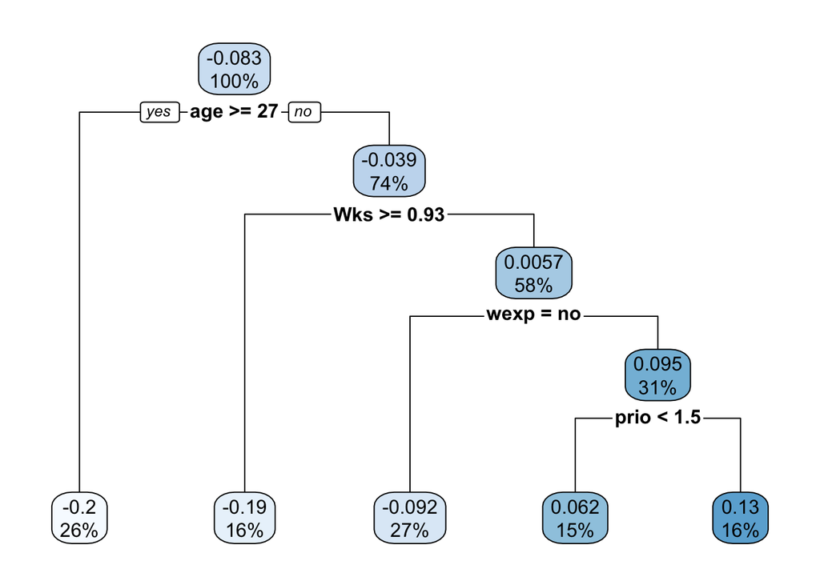

```r
rpart.plot(ACT,roundint = F)
```

Complexity table:

```r
printcp(ACT)
```

```
##
## Regression tree:
## causalTree(formula = arrest ~ ., data = RData, treatment = RData$D,
##     split.Rule = "CT", split.Honest = F, cv.option = "CT", cv.Honest = F,
##     minsize = 30)
##
## Variables actually used in tree construction:
## [1] age  prio wexp Wks
##
## Root node error: 1725/432 = 3.9931
##
## n= 432
##
##          CP nsplit rel error xerror       xstd
## 1 0.0011773      0   1.00000 1.0000 0.00015229
## 2 0.0000798      3   0.99647 1.0101 0.00103796
## 3 0.0000000      4   0.99639 1.0109 0.00105386
```

- `CP`: the complexity cost parameter value.
- `xerror`: the cross-validation error.
- `nsplit`: the number of splits.
  - The size of the tree is `nsplit+1`.

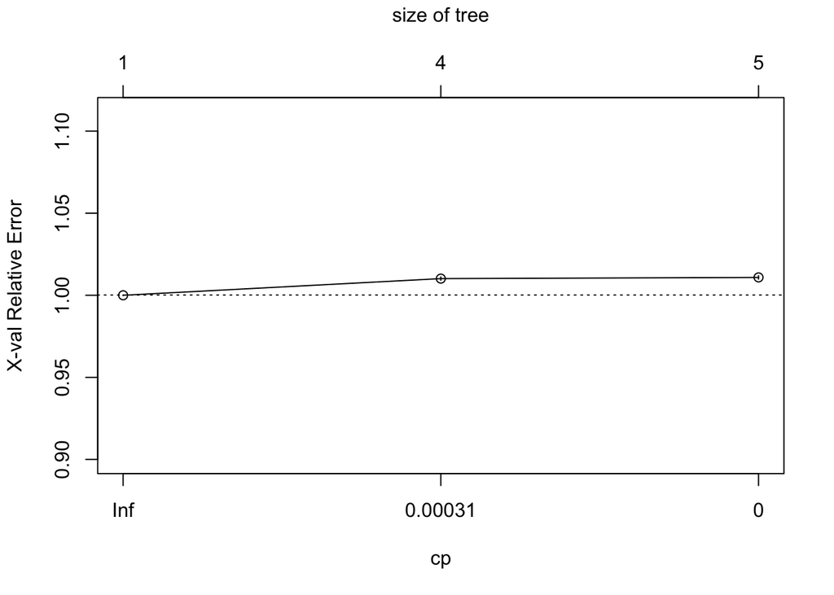

```r
plotcp(ACT)
```

Selecting the optimal complexity parameter:

```r
ID=which.min(ACT$cp[, "xerror"])
Opt_cp=ACT$cp[ID,1]
c(ID,Opt_cp)
```

```
##           1
## 1.000000000 0.001177338
```

Pruning:

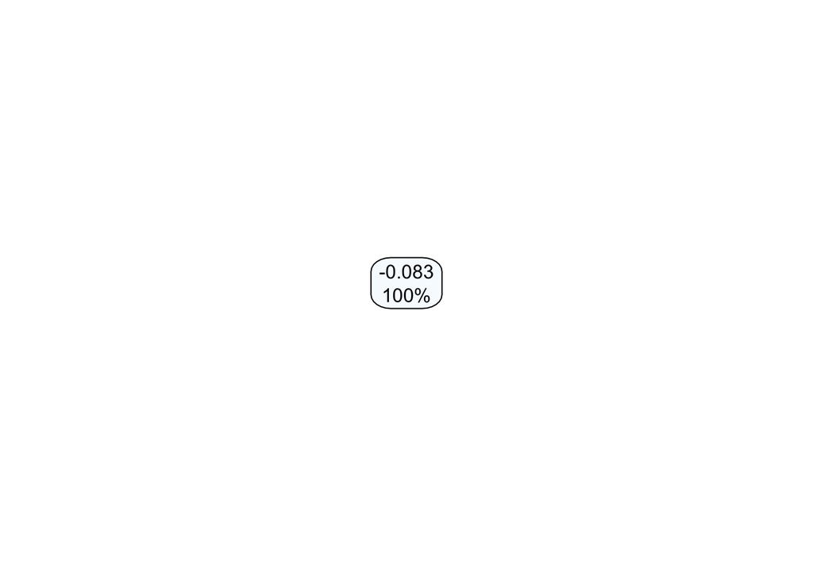

```r
ACT_prune=prune(ACT,cp=Opt_cp)
rpart.plot(ACT_prune)
```

- We are back to the simple ATE.
- Causal tree cannot detect heterogeneity

### With `honest.causalTree()`

```r
?honest.causalTree()
```

We split the sample into:

- The training sample for growing the tree.
- The estimation sample for estimating the ATE in the leafs.

```r
N<-nrow(RData)
set.seed(6064,sample.kind="Reject")
train<-sample(1:N,N/2)
RData_train<-RData[train,]
RData_est<-RData[-train,]
```

Honest tree:

```r
set.seed(6064,sample.kind="Reject")
ACT_honest<-honest.causalTree(arrest~.,
                             data=RData_train,
                             treatment=RData_train$D,
                             split.Rule="CT",
                             split.Honest = TRUE,
                             cv.option="CT",
                             cv.Honest = TRUE,
                             minsize=30,
                             est_data=RData_est,
                             est_treatment=RData_est$D
                             )
```

```
## [1] 2
## [1] "CT"
```

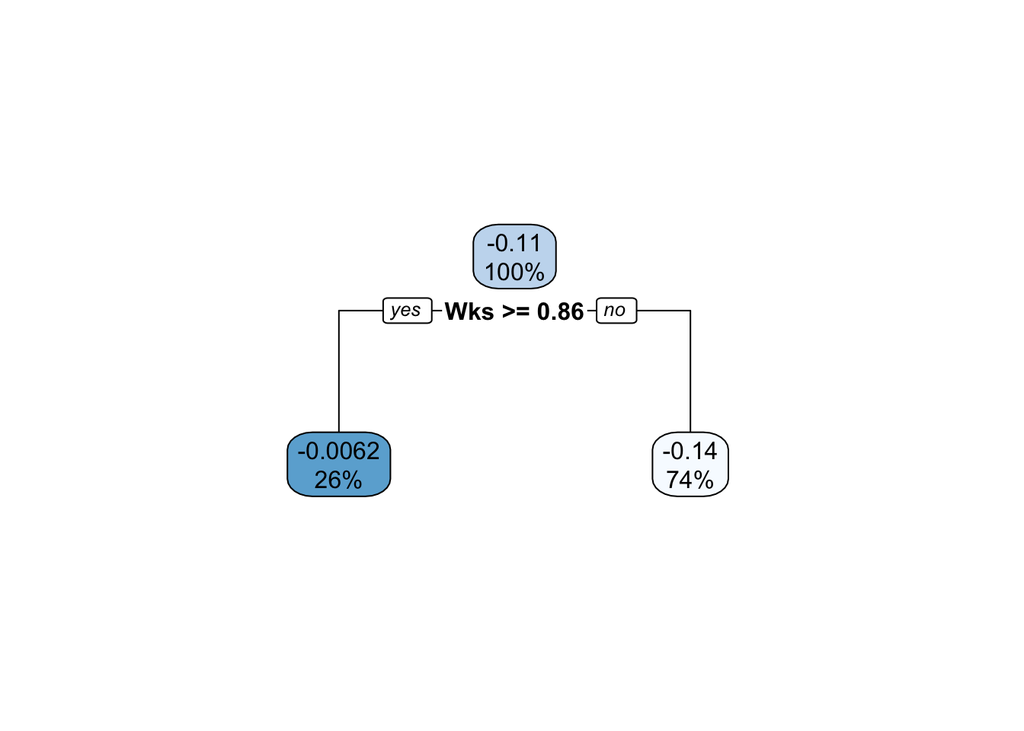

```r
rpart.plot(ACT_honest)
```

```r
printcp(ACT_honest)
```

```
##
## Regression tree:
## honest.causalTree(formula = arrest ~ ., data = RData_train, treatment = RData_train$D,
##     est_data = RData_est, est_treatment = RData_est$D, split.Rule = "CT",
##     split.Honest = TRUE, cv.option = "CT", cv.Honest = TRUE,
##     minsize = 30)
##
## Variables actually used in tree construction:
## [1] Wks
##
## Root node error: 43.147/216 = 0.19975
##
## n= 216
##
##          CP nsplit rel error  xerror       xstd
## 1 0.0017939      0   1.00000 1.00000 0.00044298
## 2 0.0000000      1   0.99821 0.99783 0.00096730
```

Pruning:

Selecting the optimal complexity parameter:

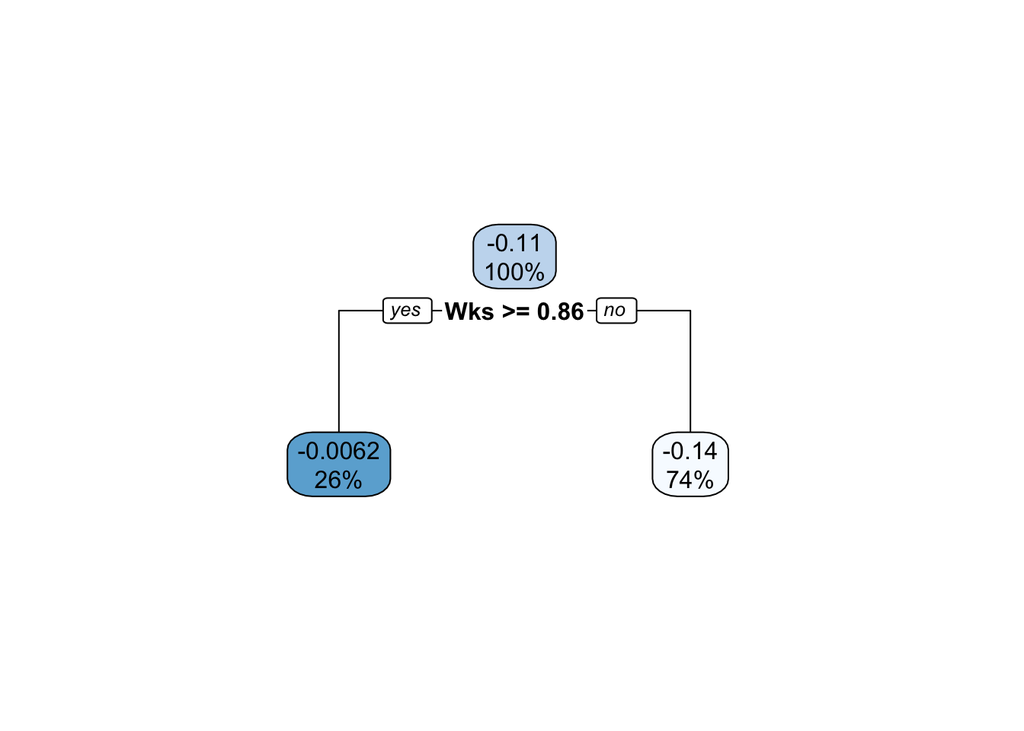

```r
ID<-which.min(ACT_honest$cp[, "xerror"])
Opt_cp<-ACT_honest$cp[ID,1]

ACT_honest_prune=prune(ACT_honest,cp=Opt_cp)
rpart.plot(ACT_honest_prune)
```

We can now split the estimation sample according to the rule for the leaves:

```r
RData_CATE<-RData_est
RData_CATE$leaf<-as.factor(round(predict(ACT_honest_prune,newdata=RData_CATE),digits=3))
table(RData_CATE$leaf)
```

```
##
## -0.136 -0.006
##    159     57
```

- We have two groups:
  - CATE = -0.136.
  - CATE = -0.006.
- It corresponds to the split according to `Wks>=0.86`.

Since the sample splitting is independent of the observations used to estimate the effect, we can now use an OLS regression with leaf dummies to obtain the standard errors.

- We include both dummies: Use `-1` to drop the intercept.
- We also drop `D` and only keep the interactions:
  - This is equivalent to running the regression `arres~D` in each leaf separately.

```r
CATE<-lm(arrest~as.factor(leaf)+D*as.factor(leaf)-1-D,data=RData_CATE)
stargazer(coeftest(CATE,vcov=vcovHC(CATE,type="HC0"))[3:4,],type="text")
```

```
##
## ===============================================================
##                         Estimate Std. Error t value Pr(> | t| )
## ---------------------------------------------------------------
## as.factor(leaf)-0.136:D  -0.136    0.066    -2.049     0.042
## as.factor(leaf)-0.006:D  -0.006    0.131    -0.048     0.962
## ---------------------------------------------------------------
```

- Note that the slope estimates on the interaction terms are identical to the leaf averages in the causal tree.

Conclusion:

- For those who holds employment at least 14% of the time, there is a significant effect of 13.6%
- The 95% CI for the group that holds employment:

```r
CATE_robust<-coeftest(CATE,vcov=vcovHC(CATE,type="HC0"))
confint(CATE_robust)[3,]
```

```
##        2.5 %       97.5 %
## -0.266905287 -0.005188473
```

- The effect is more substantial than the estimated ATE.
- The ATE is a weighted average of the CATEs for the two sub-populations.
- Since the group that cannot hold employment has a near zero effect, the ATE is lower than the CATE for the group that holds employment.
- The program should condition continuation of the financial aid on some minimal employment requirements.
- Note however that the results are sensitive to how data is split.

# Estimation of CATEs with causal forests

```r
library(grf)
?causal_forest
```

##### Estimating causal forest:

- `X=` Controls/Covariates explaining treatment assignment.
- `Y=` The outcome variables.
- `W=` The treatment variable.

```r
X<-model.matrix(D~age+race+mar+paro+prio+educ+Wks,data=RData)[,-1]
CF<-causal_forest(X=X,Y=RData$arrest,W=RData$D,seed = 6064)
```

##### CATE for `age>=27` and `age<27`:

```r
average_treatment_effect(CF,target.sample = "all",subset=(RData$age>=27))
```

```
##    estimate     std.err
## -0.18122688  0.06900634
```

```r
average_treatment_effect(CF,target.sample = "all",subset=(RData$age<27))
```

```
##    estimate     std.err
## -0.03068475  0.05071925
```

- The program is effective for older convicts.

##### CATE for `Wks>=0.85` and `Wks$<0.85`:

```r
average_treatment_effect(CF,target.sample = "all",subset=(RData$Wks>=0.85))
```

```
##   estimate    std.err
## -0.1714766  0.0887504
```

```r
average_treatment_effect(CF,target.sample = "all",subset=(RData$Wks<0.85))
```

```
##    estimate     std.err
## -0.02781201  0.04603369
```

- There seems to be a stronger effect for those who are less employed:

```r
CATE_Wks<-average_treatment_effect(CF,target.sample = "all",subset=(RData$Wks>=0.85))
Estimate=CATE_Wks[1]
Std.err=CATE_Wks[2]
T=abs(Estimate/Std.err)
pvalue=(2*(1-pnorm(T)))
cat("CATE for  Wks>0.85:  ",round(Estimate,digits=3), "  Std.err:  ",round(Std.err,digits=3), "  p-value:  ",round(pvalue,digits=3))
```

```
## CATE for  Wks>0.85:   -0.171   Std.err:   0.089   p-value:   0.053
```

##### CATEs by `race`

```r
average_treatment_effect(CF,target.sample = "all",subset=(RData$race=="black"))
```

```
##    estimate     std.err
## -0.06862071  0.04475473
```

```r
average_treatment_effect(CF,target.sample = "all",subset=(RData$race=="other"))
```

```
##    estimate     std.err
## -0.07753365  0.11542689
```

- `race` does not seem to be important

##### CATEs by `paro`

```r
average_treatment_effect(CF,target.sample = "all",subset=(RData$paro=="yes"))
```

```
##    estimate     std.err
## -0.03102023  0.05301672
```

```r
average_treatment_effect(CF,target.sample = "all",subset=(RData$paro=="no"))
```

```
##    estimate     std.err
## -0.13232807  0.06742037
```

- There seems to be a stronger effect for those who are not on parole.

```r
CATE_paro<-average_treatment_effect(CF,target.sample = "all",subset=(RData$paro=="no"))
Estimate<-CATE_paro[1]
Std.err<-CATE_paro[2]
T<-abs(Estimate/Std.err)
pvalue<-(2*(1-pnorm(T)))
cat("CATE for not on parole  :  ",round(Estimate,digits=3), "  Std.err:  ",round(Std.err,digits=3), "  p-value:  ",round(pvalue,digits=3))
```

```
## CATE for not on parole  :   -0.132   Std.err:   0.067   p-value:   0.05
```

##### CATE by prior convictions:

```r
average_treatment_effect(CF,target.sample = "all",subset=(RData$prio>1))
```

```
##    estimate     std.err
## -0.10669697  0.05395471
```

```r
average_treatment_effect(CF,target.sample = "all",subset=(RData$prio<=1))
```

```
##      estimate       std.err
## -0.0008919337  0.0642597303
```

- There seems to be a stronger effect for those with multiple prior convictions:

```r
CATE_prio<-average_treatment_effect(CF,target.sample = "all",subset=(RData$prio>1))
Estimate<-CATE_prio[1]
Std.err<-CATE_prio[2]
T<-abs(Estimate/Std.err)
pvalue<-(2*(1-pnorm(T)))
cat("CATE for prio>1  :  ",round(Estimate,digits=3), "  Std.err:  ",round(Std.err,digits=3), "  p-value:  ",round(pvalue,digits=3))
```

```
## CATE for prio>1  :   -0.107   Std.err:   0.054   p-value:   0.048
```

##### CATEs by education:

```r
table(RData$educ)
```

```
##
##      _6   10_11      12     7_9 College
##      24     119      39     239      11
```

```r
average_treatment_effect(CF,target.sample = "all",subset=(RData$educ=="_6"))
```

```
##  estimate   std.err
## -0.107516  0.167247
```

```r
average_treatment_effect(CF,target.sample = "all",subset=(RData$educ=="7_9"))
```

```
##    estimate     std.err
## -0.09445330  0.05963503
```

```r
average_treatment_effect(CF,target.sample = "all",subset=(RData$educ=="10_11"))
```

```
##    estimate     std.err
## -0.06437946  0.07597458
```

```r
average_treatment_effect(CF,target.sample = "all",subset=(RData$educ=="12"))
```

```
##   estimate    std.err
## 0.06623475 0.10736249
```

```r
average_treatment_effect(CF,target.sample = "all",subset=(RData$educ=="College"))
```

```
##   estimate    std.err
## 0.01056265 0.24922145
```

- There is no significant effect by education.

##### CATE by marital status:

```r
average_treatment_effect(CF,target.sample = "all",subset=(RData$mar=="married"))
```

```
##    estimate     std.err
## -0.05020487  0.10438716
```

```r
average_treatment_effect(CF,target.sample = "all",subset=(RData$mar=="not married"))
```

```
##    estimate     std.err
## -0.07244241  0.04527179
```

- For not married:

```r
CATE_mar<-average_treatment_effect(CF,target.sample = "all",subset=(RData$mar=="not married"))
Estimate<-CATE_mar[1]
Std.err<-CATE_mar[2]
T<-abs(Estimate/Std.err)
pvalue<-(2*(1-pnorm(T)))
cat("CATE for not married  :  ",round(Estimate,digits=3), "  Std.err:  ",round(Std.err,digits=3), "  p-value:  ",round(pvalue,digits=3))
```

```
## CATE for not married  :   -0.072   Std.err:   0.045   p-value:   0.11
```

- The program might be more effective for single convicts.

We can combine several conditions:

```r
CATE_mult<-average_treatment_effect(CF,target.sample = "all",subset=
        (
          RData$age>=27
          & RData$mar=="not married"
          & RData$prio>1
          )
        )


Estimate<-CATE_mult[1]
Std.err<-CATE_mult[2]
T<-abs(Estimate/Std.err)
pvalue<-(2*(1-pnorm(T)))
cat("CATE for age>=27, not married, with prio>1  :  ",round(Estimate,digits=3), "  Std.err:  ",round(Std.err,digits=3), "  p-value:  ",round(pvalue,digits=3))
```

```
## CATE for age>=27, not married, with prio>1  :   -0.317   Std.err:   0.114   p-value:   0.005
```

The 95% CI:

```r
CI_mult<-c(Estimate-1.96*Std.err,Estimate+1.96*Std.err)
names(CI_mult)<-c("2.5%","97.5%")
round(CI_mult,digits=3)
```

```
##   2.5%  97.5%
## -0.541 -0.093
```

We can conclude that the program is more effective for older single convicts with multiple prior convictions.

- They are less likely to have a support network.
- It is harder for them to find employment.

##### We should rely on the variables’ importance:

- There are many ways to condition: Which variables should we use for conditioning?
- `variable_importance()` computes the number of times each variable was used for splitting.

```r
CF_var_imp<-variable_importance(CF)
selected.vars <- which(CF_var_imp / mean(CF_var_imp) > 0.2)

Importance=round(CF_var_imp[selected.vars],digits=3)
names(Importance)<-colnames(X)[selected.vars]
sort(Importance, decreasing=TRUE)
```

```
##       Wks       age      prio   paroyes   educ7_9 educ10_11
##     0.364     0.285     0.188     0.057     0.042     0.027
```

CATE by the three most important variables:

```r
CATE_import<-average_treatment_effect(CF,target.sample = "all",subset=
        (
          RData$Wks<0.40
          & RData$age>=27
          & RData$prio>1
          )
        )
Estimate<-CATE_import[1]
Std.err<-CATE_import[2]
T<-abs(Estimate/Std.err)
pvalue<-(2*(1-pnorm(T)))
cat("CATE for Wks<0.4, age>=27, with prio>1  :  ",round(Estimate,digits=3), "  Std.err:  ",round(Std.err,digits=3), "  p-value:  ",round(pvalue,digits=3))
```

```
## CATE for Wks<0.4, age>=27, with prio>1  :   -0.363   Std.err:   0.126   p-value:   0.004
```

Confidence interval:

```r
CI_import<-c(Estimate-1.96*Std.err,Estimate+1.96*Std.err)
CI_import
```

```
##   estimate   estimate
## -0.6098145 -0.1153660
```

# Conclusion

```r
table<-matrix(0,2,4)
table[1,]<-c(Simple[2,1],Simple[2,2],SimpleCI)
table[2,]<-c(Estimate,Std.err,CI_import)
colnames(table)<-c("Estimate", "Std.Err" ,"2.5% CI","97.5% CI")
rownames(table)<-c("ATE","CATE with Wks<0.4, age>=27, prio>1")

table %>%
  kable(digits=2,
        caption = "Treatment effects of the financial aid program for released convicts") %>%
  kable_classic(full_width = F, html_font = "Cambria")
```

Treatment effects of the financial aid program for released convicts

|  | Estimate | Std.Err | 2.5% CI | 97.5% CI |
| --- | --- | --- | --- | --- |
| ATE | -0.08 | 0.04 | -0.17 | 0.00 |
| CATE with Wks<0.4, age>=27, prio>1 | -0.36 | 0.13 | -0.61 | -0.12 |